**CS4132 Data Analytics**

# Media Adaptations by Tyler Foo

Important Note: Please keep your report concise and relevant (i.e. show only relevant steps and visualizations used to answer your research questions).

# Table of Content (with relevant hyperlinks to sections)

- Motivation & Background
- Summary of Research Questions & Results
- Dataset
- Methodology
  - Data Acquisition
  - Data Cleaning
  - EDA
    - Question 1
    - Question 2
- Results
  - Question 1
  - Question 2
- Recommendations

# Motivation and Background

Give an overview of the project, motivation, background and goals.

Stories can be told through various mediums, and can be retold in different ways through adaptation of the source material into other media. This offers a new experience to a familiar title, especially for fans of the original material, and allows creators to make more money from their intellectual property. I believe that such adaptations are becoming more popular to create recently for these reasons, and would like to investigate more on their history and whether they really are profitable at all.

# Summary of Research Questions & Results

Repeat your research questions in a numbered list. After each research question, clearly state the answer/conclusion you determined. Do not give details or justifications yet — just the answer

1. How has the number and popularity of adaptations created changed over time?
- Their numbers have generally increased but have been decreasing recently.
- Novel to film adaptations have become more popular recently, but there is no significant trend.
1. How well do film adaptations sell?
- Very well.

# Dataset

Numbered list of dataset (with downloadable links) and a brief but clear description of each dataset used. Draw reference to the numbering when describing methodology (data cleaning and analysis).

1. https://en.wikipedia.org
- Wikipedia contains lists of adaptations that currently exist. (full links in scraping file)
1. https://www.the-numbers.com
- Movie data
1. https://www.vgchartz.com
- Video games data
1. https://docs.google.com/spreadsheets/d/1A33miTSU1NHdVO7F8kMT68wgkM6uW8YThKPEsDvLKsc/edit#gid=427506025
- Anime data

# Methodology

You should demonstrate the data science life cycle here (from data acquisition to cleaning to EDA and analysis etc).

## Data Acquisition

Display the data which will be used in the project. The data should be saved in .xlsx or .csv format to be submitted with the project. If webscraping has been done to obtain your data, save your webscraping code in another jupyter notebook as appendix to be submitted separately from the report. Import and display each dataset in a dataframe. For each dataset, give a brief overview of the data it contains, and explain the meaning of columns that are relevant to the project.

```python
import pandas as pd, numpy as np, matplotlib.pyplot as plt, seaborn as sns
from scipy import stats
```

```python
# suppress scientific notation
pd.set_option('display.float_format', '{:.2f}'.format)
```

```python
# import datasets
anime_data = pd.read_csv("anime_data.csv")
film_budgets_data = pd.read_csv("film_budgets.csv")
film_sales_data = pd.read_csv("film_sales.csv")
vg_data = pd.read_csv("vg_data.csv")

anime_vg_data = pd.read_csv("anime-vg.csv")
film_novel_data = pd.read_csv("film-novel.csv")
film_vg_data = pd.read_csv("film-vg.csv")
novel_animanga_data = pd.read_csv("novel-animanga.csv")
novel_film_data = pd.read_csv("novel-film.csv")
novel_vg_data = pd.read_csv("novel-vg.csv")
vg_anime_data = pd.read_csv("vg-anime.csv")
vg_film_data = pd.read_csv("vg-film.csv")
```

The anime sales shown are disc sales, so the "avg sales" value shown represents the average sales of all the disc volumes released.

```python
anime_data.head()
```

|  | Series Title | Type | Season | Year | Sales Avg, Initial Release | Sales Avg, Re-releases | Sales Avg, Total | Revenue\n(Initial Release) | Source Material | Animation Studio | Publisher | Distributor | 万円 |
| --- | --- | --- | --- | --- | --- | --- | --- | --- | --- | --- | --- | --- | --- |
| 0 | .hack//SIGN | TV | Spring | 2002 | 6,032 | 0 | 6,032 | ¥362,220,000 | game | Bee Train | Bandai Visual | Bandai Visual | ¥36,222 |
| 1 | .hack//Tasogare no Udewa Densetsu | TV | Winter | 2003 | 2,954 | 0 | 2,954 | ¥102,810,000 | game | Bee Train | Bandai Visual | Bandai Visual | ¥10,281 |
| 2 | .hack//Roots | TV | Spring | 2006 | 2,138 | 0 | 2,138 | ¥113,000,000 | game | Bee Train | Bandai Visual | Bandai Visual | ¥11,300 |
| 3 | 009-1 | TV | Fall | 2006 | 1,258 | 0 | 1,258 | ¥46,390,000 | manga | Ishimori Entertainment | Aniplex | Sony | ¥4,639 |
| 4 | 07-Ghost | TV | Spring | 2009 | 2,529 | 0 | 2,529 | ¥197,230,000 | manga | Studio Deen | Avex | Avex | ¥19,723 |

```python
film_budgets_data.head()
```

|  | Release Date | Movie | Production Budget | Domestic Gross | Worldwide Gross |
| --- | --- | --- | --- | --- | --- |
| 0 | Apr 23, 2019 | Avengers: Endgame | $400,000,000 | $858,373,000 | $2,797,800,564 |
| 1 | May 20, 2011 | Pirates of the Caribbean: On Stranger Tides | $379,000,000 | $241,071,802 | $1,045,713,802 |
| 2 | Apr 22, 2015 | Avengers: Age of Ultron | $365,000,000 | $459,005,868 | $1,395,316,979 |
| 3 | Dec 16, 2015 | Star Wars Ep. VII: The Force Awakens | $306,000,000 | $936,662,225 | $2,064,615,817 |
| 4 | Apr 25, 2018 | Avengers: Infinity War | $300,000,000 | $678,815,482 | $2,048,359,754 |

```python
film_sales_data.head()
```

|  | Year | Movie | Worldwide Box Office | Domestic Box Office | International Box Office |
| --- | --- | --- | --- | --- | --- |
| 0 | 2009 | Avatar | $2,905,940,950 | $779,416,377 | $2,126,524,573 |
| 1 | 2019 | Avengers: Endgame | $2,797,800,564 | $858,373,000 | $1,939,427,564 |
| 2 | 1997 | Titanic | $2,207,986,545 | $659,363,944 | $1,548,622,601 |
| 3 | 2015 | Star Wars Ep. VII: The Force Awakens | $2,064,615,817 | $936,662,225 | $1,127,953,592 |
| 4 | 2018 | Avengers: Infinity War | $2,048,359,754 | $678,815,482 | $1,369,544,272 |

```python
vg_data.head()
```

|  | Title | Console | Publisher | VGChartz Score | Critic Score | Total Shipped | Total Sales | Release Date |
| --- | --- | --- | --- | --- | --- | --- | --- | --- |
| 0 | Tetris | Series | Nintendo | NaN | NaN | 496.40m | NaN | 31st Jul 89 |
| 1 | Pokemon | Series | Nintendo | NaN | NaN | 440.50m | NaN | 28th Sep 98 |
| 2 | Call of Duty | Series | Activision | NaN | NaN | 400.00m | NaN | 29th Oct 03 |
| 3 | Super Mario | Series | Nintendo | NaN | NaN | 394.47m | NaN | 20th Jul 83 |
| 4 | Grand Theft Auto | Series | Rockstar Games | NaN | NaN | 380.00m | NaN | 27th Mar 98 |

```python
anime_vg_data.head()
```

|  | Title |
| --- | --- |
| 0 | 7 Blades |
| 1 | Aah! Harimanada |
| 2 | Accel World: Ginyoku no Kakusei |
| 3 | Accel World: Kasoku no Chōten |
| 4 | Ace wo Nerae! |

```python
film_novel_data.head()
```

|  | Franchise | Title | Author(s) | ISBN | Publisher | Notes | Author | Release Date |
| --- | --- | --- | --- | --- | --- | --- | --- | --- |
| 0 | Bad News Bears | The Bad News Bears (1976) | Richard Woodley | 0-440-90823-X/978-0-440-90823-4 | Dell Publishing | Novelization of the film | NaN | NaN |
| 1 | Bad News Bears | The Bad News Bears in Breaking Training (1977) | Richard Woodley | 0-440-10417-3/978-0-440-10417-9 | Dell Publishing | Novelization of the film | NaN | NaN |
| 2 | Bad News Bears | The Bad News Bears Go to Japan (1978) | Richard Woodley | 0-440-10427-0/978-0-440-10427-8 | Dell Publishing | Novelization of the film | NaN | NaN |
| 3 | Blade Runner | Blade Runner: A Story of the Future (1982) | Les Martin | 0-394-85303-2 | Random House | Novelization of the film | NaN | NaN |
| 4 | Blade Runner | Blade Runner 2: The Edge of Human (1995) | K. W. Jeter | 0-553-09979-5/978-0-553-09979-9 | Bantam Books | Sequel novel to the original film | NaN | NaN |

```python
film_vg_data.head()
```

|  | Name | Year | Developer | Publisher | Film |
| --- | --- | --- | --- | --- | --- |
| 0 | 3 Ninjas Kick Back (video game) | 1994 | Malibu Interactive | Sony Imagesoft | 3 Ninjas Kick Back |
| 1 | 007: Licence to Kill | 1989 | Quixel | Domark | Licence to Kill |
| 2 | 007 Legends | 2012 | Eurocom | Activision | Goldfinger, On Her Majesty's Secret Service, M... |
| 3 | 102 Dalmatians: Puppies to the Rescue | 2000 | Crystal Dynamics | Eidos Interactive (PS1, PC, DC) Activision (GBC) | 102 Dalmatians |
| 4 | 300: March to Glory | 2007 | Collision Studios | Warner Bros. Games | 300 |

```python
novel_animanga_data.head()
```

|  | Title |
| --- | --- |
| 0 | Attack on Titan: Lost Girls |
| 1 | Babylon (novel series) |
| 2 | Basilisk (manga) |
| 3 | Bōkyaku Tantei |
| 4 | Captain Future |

```python
novel_film_data.head()
```

|  | Fiction work(s) | Film adaptation(s) |
| --- | --- | --- |
| 0 | The A.B.C. Murders (1936), Agatha Christie | The Alphabet Murders (1966) The A.B.C. Murders... |
| 1 | À ton image (1998), Louise L. Lambrichs | À ton image (2004) |
| 2 | About a Boy (1998), Nick Hornby | About a Boy (2002) |
| 3 | About Schmidt (1996), Louis Begley | About Schmidt (2002) |
| 4 | Absolute Power (1996), David Baldacci | Absolute Power (1997) |

```python
novel_vg_data.head()
```

|  | Title |
| --- | --- |
| 0 | 100 Classic Book Collection |
| 1 | La Abadía del Crimen |
| 2 | Agatha Christie: The ABC Murders (2009 video g... |
| 3 | Age of Pirates: Captain Blood |
| 4 | Amazon (video game) |

```python
vg_anime_data.head()
```

|  | Anime | Video game | Year | Type |
| --- | --- | --- | --- | --- |
| 0 | 11eyes | 11eyes: Tsumi to Batsu to Aganai no Shōjo | 2009 | TV series |
| 1 | Ace Attorney | Ace Attorney | 2016 – 2019 | TV series |
| 2 | Air | Air | 2005 | TV series |
| 3 | Air | Air | 2005 | Film |
| 4 | Akaneiro ni Somaru Saka | Akaneiro ni Somaru Saka | 2008 | TV series |

```python
vg_film_data.head()
```

|  | Title | Release date | Worldwide box office | Rotten Tomatoes | Metacritic | Distributor | Original game publisher | Domestic box office |
| --- | --- | --- | --- | --- | --- | --- | --- | --- |
| 0 | Super Mario Bros. | May 28, 1993 | $38,912,465[2] | 24%[3] | 35/100[4] | Buena Vista Pictures Distribution | Nintendo | NaN |
| 1 | Double Dragon | November 4, 1994 | $4,152,699[b] | 13%[5] | NaN | Gramercy Pictures | Technōs Japan | NaN |
| 2 | Street Fighter | December 23, 1994 | $99,423,521[6] | 13%[7] | 34/100[8] | Universal Pictures | Capcom | NaN |
| 3 | Mortal Kombat | August 18, 1995 | $124,741,822[c] | 44%[9] | 60/100[10] | New Line Cinema | Midway | NaN |
| 4 | Mortal Kombat: Annihilation | November 21, 1997 | $51,376,861[11] | 2%[12] | 11/100[13] | New Line Cinema | Midway | NaN |

## Data Cleaning

For data cleaning, be clear in which dataset (or variables) are used, what has been done for missing data, how was merging performed, explanation of data transformation (if any). If data is calculated or summarized from the raw dataset, explain the rationale and steps clearly.

I will start with cleaning the film data.

```python
# Make a 'Year' column for film_budgets_data
film_budgets_data['Year'] = pd.to_numeric(film_budgets_data['Release Date'].str[-4:], errors='coerce')
film_budgets_data.head()
```

|  | Release Date | Movie | Production Budget | Domestic Gross | Worldwide Gross | Year |
| --- | --- | --- | --- | --- | --- | --- |
| 0 | Apr 23, 2019 | Avengers: Endgame | $400,000,000 | $858,373,000 | $2,797,800,564 | 2019.00 |
| 1 | May 20, 2011 | Pirates of the Caribbean: On Stranger Tides | $379,000,000 | $241,071,802 | $1,045,713,802 | 2011.00 |
| 2 | Apr 22, 2015 | Avengers: Age of Ultron | $365,000,000 | $459,005,868 | $1,395,316,979 | 2015.00 |
| 3 | Dec 16, 2015 | Star Wars Ep. VII: The Force Awakens | $306,000,000 | $936,662,225 | $2,064,615,817 | 2015.00 |
| 4 | Apr 25, 2018 | Avengers: Infinity War | $300,000,000 | $678,815,482 | $2,048,359,754 | 2018.00 |

```python
# First, we want to merge the film budgets and sales data into a single dataframe.
# To do this, we will need to merge on both the movie title and release year,
# since some movies have the same title but different release years.
film_data = pd.merge(film_sales_data, film_budgets_data, how='outer', on=['Movie', 'Year'])

# formatting numerical columns
film_data[['Production Budget','Worldwide Box Office','Worldwide Gross']]\
    = film_data[['Production Budget','Worldwide Box Office','Worldwide Gross']]\
        .replace(regex='[\$,]', value='').astype(float)

# Since the 'WorldwideBox Office' and 'WorldwideGross' columns represent the same data,
# I will take the sales to be the larger value between the two columns in each row,
# as it is likely the more recent value.
film_data['Sales'] = film_data[['Worldwide Box Office','Worldwide Gross']].fillna(0).max(axis=1)

# taking useful columns
film_data = film_data.iloc[:,[1,5,6,9]].copy()

# removing all empty values and duplicates
mask = (film_data['Sales'] == 0) | (film_data['Release Date'] == 'Unknown')
film_data = film_data.drop(film_data[mask].index).drop_duplicates().reset_index(drop=True)

# format date
film_data['Release Date'] = pd.to_datetime(film_data['Release Date'])

film_data.head()
```

|  | Movie | Release Date | Production Budget | Sales |
| --- | --- | --- | --- | --- |
| 0 | Avatar | 2009-12-17 | 237000000.00 | 2905940950.00 |
| 1 | Avengers: Endgame | 2019-04-23 | 400000000.00 | 2797800564.00 |
| 2 | Titanic | 1997-12-18 | 200000000.00 | 2207986545.00 |
| 3 | Star Wars Ep. VII: The Force Awakens | 2015-12-16 | 306000000.00 | 2064615817.00 |
| 4 | Avengers: Infinity War | 2018-04-25 | 300000000.00 | 2048359754.00 |

```python
film_data['Production Budget'].isna().value_counts()
```

```
True     29414
False     5875
Name: Production Budget, dtype: int64
```

Since most values in ProductionBudget are NaN, I will not clean that column.

Now to the anime data.

```python
# renaming columns
anime_data = anime_data.rename(columns={
    'Series Title': 'Title',
    'Sales Avg, Initial Release': 'InitialAvgSales',
    'Sales Avg, Total': 'TotalAvgSales',
    'Revenue\n(Initial Release)': 'InitialRevenue',
    'Source Material': 'SourceMaterial'
    })

# dropping unneeded data
mask = (anime_data['SourceMaterial'] != 'original') & (anime_data['InitialRevenue'] != 0)
anime_data = anime_data[mask].iloc[:,[0,1,2,3,4,6,7,8]]\
    .drop_duplicates().reset_index(drop=True)

# formatting numerical columns
anime_data[anime_data.columns[[4,5,6]]] = anime_data[anime_data.columns[[4,5,6]]]\
    .replace(regex='[¥,]', value='').astype(float)

anime_data.head()
# TODO check (initial releases) for revenue, do i need to math it
```

|  | Title | Type | Season | Year | InitialAvgSales | TotalAvgSales | InitialRevenue | SourceMaterial |
| --- | --- | --- | --- | --- | --- | --- | --- | --- |
| 0 | .hack//SIGN | TV | Spring | 2002 | 6032.00 | 6032.00 | 362220000.00 | game |
| 1 | .hack//Tasogare no Udewa Densetsu | TV | Winter | 2003 | 2954.00 | 2954.00 | 102810000.00 | game |
| 2 | .hack//Roots | TV | Spring | 2006 | 2138.00 | 2138.00 | 113000000.00 | game |
| 3 | 009-1 | TV | Fall | 2006 | 1258.00 | 1258.00 | 46390000.00 | manga |
| 4 | 07-Ghost | TV | Spring | 2009 | 2529.00 | 2529.00 | 197230000.00 | manga |

Now to the video games data.

```python
# renaming columns
vg_data = vg_data.rename(columns={
    'Critic Score': 'CriticScore',
    'Total Sales': 'SalesInMillions',
    'Release Date': 'ReleaseDate'
})

# For all rows, there is always data in either the Total Shipped column or the Total Sales column,
# but never both.
# For the sake of simplicity, I will therefore take them to represent the same data
# and merge the columns.
vg_data['SalesInMillions'] = vg_data['SalesInMillions'].fillna(vg_data['Total Shipped'])

# Similarly, I will merge the VGChartz Score and CriticScore columns.
# In this case, I will take the CriticScore column to be more reliable
# since it averages ratings from various sources.
vg_data['CriticScore'] = vg_data['CriticScore'].fillna(vg_data['VGChartz Score'])

# formatting columns
vg_data['SalesInMillions'] = pd.to_numeric(vg_data['SalesInMillions'].str[:-1])
vg_data['ReleaseDate'] = pd.to_datetime(
    vg_data['ReleaseDate'].replace(regex='(\d)(st|nd|rd|th)', value='\\1'),
    format="%d %b %y")

# dropping unneeded data
vg_data = vg_data[vg_data['SalesInMillions']!=0.0].iloc[:,[0,1,4,6,7]]\
    .drop_duplicates().reset_index(drop=True)
vg_data = vg_data[vg_data['Console'] != 'Series']

# remove duplicates if there is an entry with console 'All'
consoles = vg_data.groupby('Title')['Console'].apply(''.join)
has_all = consoles[consoles.str.contains('All') & (consoles.str.len()>3)].index
has_all = vg_data[vg_data['Title'].isin(has_all)].drop_duplicates(subset='Title')
vg_data = vg_data[~vg_data['Title'].isin(has_all['Title'])]\
    .merge(has_all, how='outer')

# merge sales in rows with the same title but different console
vg_data['SalesInMillions'] = vg_data.groupby('Title')['SalesInMillions']\
    .transform('sum')
vg_data = vg_data.drop_duplicates(subset=['Title'])\
    .sort_values(by=['SalesInMillions', 'Title'], ascending=False)\
        .reset_index(drop=True).iloc[:,[0,2,3,4]]
vg_data.head()
```

|  | Title | CriticScore | SalesInMillions | ReleaseDate |
| --- | --- | --- | --- | --- |
| 0 | Minecraft | NaN | 238.00 | 2011-11-18 |
| 1 | Grand Theft Auto V | NaN | 170.00 | 2013-09-17 |
| 2 | Wii Sports | 7.70 | 82.90 | 2006-11-19 |
| 3 | PlayerUnknown's Battlegrounds | NaN | 70.00 | 2017-12-17 |
| 4 | Mario Kart 8 Deluxe | 9.30 | 46.82 | 2017-04-28 |

Next will be the cleaning of the adaptations data.  
For most of these, I will merge the tables with the corresponding medium data, since these tables mostly only list the titles. This results in a large amount of NaN due to the limitations of merging on the names, which is inaccurate in most cases, but this is the only option available.

```python
anime_vg_data = anime_vg_data\
    .replace('ō', 'ou', regex=True).replace('Ō', 'Ou', regex=True)\
    .merge(vg_data, how='left', on='Title')\
    .rename(columns={'ReleaseDate': 'AdaptReleaseDate'})
anime_vg_data.head()
```

|  | Title | CriticScore | SalesInMillions | AdaptReleaseDate |
| --- | --- | --- | --- | --- |
| 0 | 7 Blades | NaN | NaN | NaT |
| 1 | Aah! Harimanada | NaN | NaN | NaT |
| 2 | Accel World: Ginyoku no Kakusei | NaN | 0.06 | 2012-09-13 |
| 3 | Accel World: Kasoku no Chouten | NaN | 0.03 | 2013-01-31 |
| 4 | Ace wo Nerae! | NaN | NaN | NaT |

```python
film_novel_data = film_novel_data[film_novel_data.columns[[0,1,3,7]]]

# remove the reference brackets
film_novel_data = film_novel_data.replace(regex='\[.*?\]', value='')

# fill in NaN release years
years = film_novel_data['Title'].str.extractall('\((\d{4})\)')[0]
years.index = years.index.droplevel(level=1)
film_novel_data.loc[years.index.get_level_values(0), 'Release Date'] =\
    film_novel_data.loc[years.index.get_level_values(0), 'Release Date'].fillna(years)

# Some release dates specify the month or even the day
# For consistency, I will only keep the year
film_novel_data = film_novel_data.dropna(subset='Release Date')
film_novel_data['Release Date'] = film_novel_data['Release Date'].str[-4:].astype(int)

# drop useless characters
film_novel_data['Title'] = film_novel_data['Title'].replace(' \(\d{4}\)', '', regex=True)
film_novel_data['ISBN'] = film_novel_data['ISBN'].str.split('/').str[0].replace('-', '', regex=True)

film_novel_data = film_novel_data.rename(columns={'Release Date': 'Year'})
film_novel_data.head()
```

|  | Franchise | Title | ISBN | Year |
| --- | --- | --- | --- | --- |
| 0 | Bad News Bears | The Bad News Bears | 044090823X | 1976 |
| 1 | Bad News Bears | The Bad News Bears in Breaking Training | 0440104173 | 1977 |
| 2 | Bad News Bears | The Bad News Bears Go to Japan | 0440104270 | 1978 |
| 3 | Blade Runner | Blade Runner: A Story of the Future | 0394853032 | 1982 |
| 4 | Blade Runner | Blade Runner 2: The Edge of Human | 0553099795 | 1995 |

```python
# remove brackets
film_vg_data = film_vg_data.replace(regex='\(.*?\)|\[.*?\]', value='')\
    .merge(vg_data, how='left', left_on='Name', right_on='Title')\
    .merge(film_data, how='left', left_on='Film', right_on='Movie')\
    .iloc[:,[0,1,4,6,7,10,11,12]]\
    .rename(columns={'ReleaseDate': 'AdaptReleaseDate'})
film_vg_data = film_vg_data[film_vg_data['Year'].str.contains('\d')]
film_vg_data['Year'] = film_vg_data['Year'].astype(int)
film_vg_data.head()
```

|  | Name | Year | Film | CriticScore | SalesInMillions | Release Date | Production Budget | Sales |
| --- | --- | --- | --- | --- | --- | --- | --- | --- |
| 0 | 3 Ninjas Kick Back | 1994 | 3 Ninjas Kick Back | NaN | NaN | 1994-05-06 | 20000000.00 | 11744960.00 |
| 1 | 007: Licence to Kill | 1989 | Licence to Kill | NaN | NaN | 1989-07-14 | 42000000.00 | 156167015.00 |
| 2 | 007 Legends | 2012 | Goldfinger, On Her Majesty's Secret Service, M... | NaN | 0.76 | NaT | NaN | NaN |
| 3 | 102 Dalmatians: Puppies to the Rescue | 2000 | 102 Dalmatians | NaN | NaN | 2000-11-22 | 85000000.00 | 66941559.00 |
| 4 | 300: March to Glory | 2007 | 300 | 4.90 | 0.41 | 2007-03-09 | 60000000.00 | 454161935.00 |

```python
novel_animanga_data = novel_animanga_data.replace(regex='\(.*?\)', value='')\
    .merge(anime_data, how='left', on='Title').dropna().reset_index(drop=True)
novel_animanga_data.head()
```

|  | Title | Type | Season | Year | InitialAvgSales | TotalAvgSales | InitialRevenue | SourceMaterial |
| --- | --- | --- | --- | --- | --- | --- | --- | --- |
| 0 | Clione no Akari | TV | Summer | 2017.00 | 0.00 | 0.00 | 0.00 | novel |
| 1 | Hakata Tonkotsu Ramens | TV | Winter | 2018.00 | 1122.00 | 1122.00 | 33000000.00 | novel |
| 2 | Hyouka | TV | Spring | 2012.00 | 10046.00 | 22292.00 | 759730000.00 | novel |
| 3 | Ikebukuro West Gate Park | TV | Fall | 2020.00 | 314.00 | 314.00 | 5420000.00 | novel |
| 4 | Log Horizon | TV | Fall | 2013.00 | 4026.00 | 4828.00 | 245080000.00 | novel |

```python
# renaming columns
novel_film_data.columns = ['Original', 'Adaptation']

# extracting release year
novel_film_data = novel_film_data.merge(
    novel_film_data['Original'].str.extractall('\((\d{4})s?\)').groupby(level=0)\
        .agg(list).rename(columns={0:'OriginalReleaseYear'}),
    how='left', left_index=True, right_index=True)

# same thing, regex does not include 's?' as those cases are not in this column
novel_film_data = novel_film_data.merge(
    novel_film_data['Adaptation'].str.extractall('\((\d{4})\)').groupby(level=0)\
        .agg(list).rename(columns={0:'AdaptReleaseYear'}),
    how='left', left_index=True, right_index=True)

# remove bracketed parts
#novel_film_data = novel_film_data.replace('\(.*\)', '', regex=True)

# extracting titles
novel_film_data = novel_film_data.merge(
    novel_film_data['Original'].str.split('\*+ *\**|(?<=[a-z])(?=[A-Z])').rename('OriginalTitle'),
    how='left', left_index=True, right_index=True)
novel_film_data = novel_film_data.merge(
    novel_film_data['Adaptation'].str.split('\*+ *\**|(?<=\))(?=[A-Z])').rename('AdaptTitle'),
    how='left', left_index=True, right_index=True)

# remove entries with '(series)'
mask = novel_film_data['OriginalTitle'].str.len() >\
    novel_film_data['OriginalReleaseYear'].str.len(), 'OriginalTitle'
novel_film_data.loc[mask] = novel_film_data.loc[mask].str[1:]

def clean_title(s):
    novel_film_data[s] = novel_film_data[s].map(lambda l: list(map(lambda s: s.split(' (')[0], l)))
clean_title('OriginalTitle')
clean_title('AdaptTitle')

novel_film_data = novel_film_data.dropna(subset=['OriginalReleaseYear', 'AdaptReleaseYear'])
novel_film_data = novel_film_data.drop(columns=['Original', 'Adaptation'])
novel_film_data.head()
```

|  | OriginalReleaseYear | AdaptReleaseYear | OriginalTitle | AdaptTitle |
| --- | --- | --- | --- | --- |
| 0 | [1936] | [1966, 1992] | [The A.B.C. Murders] | [The Alphabet Murders] |
| 1 | [1998] | [2004] | [À ton image] | [À ton image] |
| 2 | [1998] | [2002] | [About a Boy] | [About a Boy] |
| 3 | [1996] | [2002] | [About Schmidt] | [About Schmidt] |
| 4 | [1996] | [1997] | [Absolute Power] | [Absolute Power] |

```python
# film data using the list above
novel_film_films = pd.merge(film_data, novel_film_data['AdaptTitle'].explode(),
    how='right', left_on='Movie', right_on='AdaptTitle')

# drop extra title column and move title to first column
columns = novel_film_films.columns.tolist()[1:]
columns.insert(0, columns.pop())
novel_film_films = novel_film_films[columns]\
    .rename(columns={'Release Date': 'AdaptReleaseDate'})
novel_film_films.head()
```

|  | AdaptTitle | AdaptReleaseDate | Production Budget | Sales |
| --- | --- | --- | --- | --- |
| 0 | The Alphabet Murders | NaT | NaN | NaN |
| 1 | À ton image | NaT | NaN | NaN |
| 2 | About a Boy | 2002-05-17 | 27000000.00 | 130759651.00 |
| 3 | About Schmidt | 2002-12-13 | 30000000.00 | 107054484.00 |
| 4 | Absolute Power | 1997-02-14 | 50000000.00 | 50068310.00 |

```python
novel_vg_data = novel_vg_data.replace(regex='\(.*?\)', value='')\
    .merge(vg_data, how='left', on='Title')\
    .rename(columns={'ReleaseDate': 'AdaptReleaseDate'})
novel_vg_data.head()
```

|  | Title | CriticScore | SalesInMillions | AdaptReleaseDate |
| --- | --- | --- | --- | --- |
| 0 | 100 Classic Book Collection | NaN | NaN | NaT |
| 1 | La Abadía del Crimen | NaN | NaN | NaT |
| 2 | Agatha Christie: The ABC Murders | NaN | NaN | NaT |
| 3 | Age of Pirates: Captain Blood | NaN | NaN | NaT |
| 4 | Amazon | NaN | NaN | NaT |

```python
vg_anime_data = vg_anime_data.replace(regex='\(.*?\)|\[.*?\]', value='')\
    .merge(anime_data, how='left', left_on='Anime', right_on='Title')\
    .merge(vg_data, how='left', left_on='Video game', right_on='Title')
vg_anime_data = vg_anime_data.iloc[:,[0,1,2,3,8,9,10,13,14,15]]\
    .rename(columns={'Type_x': 'Type', 'Year_x': 'Year', 'Year_y': 'OriginalReleaseYear'})
vg_anime_data['Year'] = vg_anime_data['Year'].str[:4].astype(int)
vg_anime_data.head()
```

|  | Anime | Video game | Year | Type | InitialAvgSales | TotalAvgSales | InitialRevenue | CriticScore | SalesInMillions | ReleaseDate |
| --- | --- | --- | --- | --- | --- | --- | --- | --- | --- | --- |
| 0 | 11eyes | 11eyes: Tsumi to Batsu to Aganai no Shōjo | 2009 | TV series | 656.00 | 656.00 | 18360000.00 | NaN | NaN | NaT |
| 1 | Ace Attorney | Ace Attorney | 2016 | TV series | NaN | NaN | NaN | NaN | NaN | NaT |
| 2 | Air | Air | 2005 | TV series | NaN | NaN | NaN | NaN | 0.02 | 2016-09-08 |
| 3 | Air | Air | 2005 | Film | NaN | NaN | NaN | NaN | 0.02 | 2016-09-08 |
| 4 | Akaneiro ni Somaru Saka | Akaneiro ni Somaru Saka | 2008 | TV series | NaN | NaN | NaN | NaN | NaN | NaT |

```python
# drop unreleased movies
vg_film_data = vg_film_data[~vg_film_data['Worldwide box office'].str.contains('TBA|Upcoming', na=False)]
vg_film_data = vg_film_data.iloc[:,[0,1]]

# remove the reference brackets
vg_film_data = vg_film_data.replace(regex='\[.*?\]', value='')

# formatting
vg_film_data.columns = ['Title', 'ReleaseDate']
vg_film_data['ReleaseDate'] = vg_film_data['ReleaseDate'].str.split(' \(').str[0]
vg_film_data['ReleaseDate'] = pd.to_datetime(vg_film_data['ReleaseDate'])
vg_film_data = vg_film_data.reset_index(drop=True)

# merge with film data
vg_film_data = vg_film_data.merge(film_data, how='left',
    left_on=['Title', 'ReleaseDate'], right_on=['Movie', 'Release Date'])\
    .iloc[:,[0,1,4,5]]\
    .rename(columns={'ReleaseDate': 'AdaptReleaseDate'})

vg_film_data.head()
```

|  | Title | AdaptReleaseDate | Production Budget | Sales |
| --- | --- | --- | --- | --- |
| 0 | Super Mario Bros. | 1993-05-28 | 42000000.00 | 20844907.00 |
| 1 | Double Dragon | 1994-11-04 | NaN | NaN |
| 2 | Street Fighter | 1994-12-23 | 35000000.00 | 99423000.00 |
| 3 | Mortal Kombat | 1995-08-18 | 20000000.00 | 122133227.00 |
| 4 | Mortal Kombat: Annihilation | 1997-11-21 | 30000000.00 | 51327406.00 |

```python
df_list = [anime_vg_data, film_novel_data, film_vg_data, novel_animanga_data, novel_film_data, novel_vg_data, vg_anime_data, vg_film_data]
df_strings = ['Anime to Games', 'Films to Novels', 'Films to Games', 'Novels to Anime/Manga', 'Novels to Films', 'Novels to Games', 'Games to Anime', 'Games to Films']
```

## EDA

For each research questions shortlisted, outline your methodology in answering them. Discuss interesting observations or results discovered. Please note to only show EDA that's relevant to answering the question at hand. If you have done any data modeling, include in this section.

### Q1. How has the number and popularity of adaptations created changed over time?

I will first plot a histogram for all of the categories combined.

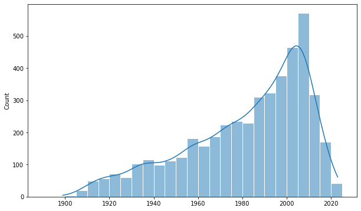

```python
# extract release years
def dates_data(df: pd.DataFrame):
    if 'AdaptReleaseDate' in df.columns:
        return df['AdaptReleaseDate'].dt.year
    elif 'Year' in df.columns:
        return df['Year'].dropna().astype(int)
    else:
        return df['AdaptReleaseYear'].explode().astype(int)

plt.figure(figsize=(10,6))
dates = pd.concat(list(map(dates_data, df_list)))
sns.histplot(dates, bins=range(1890,2026,5), edgecolor='w', kde=True);
```

From the graph, it seems that 2005-2010 was the period of time with the most adaptations, and 2005 in particular was the peak.  
The number of adaptations increased up to almost 600 from 2005-2010, and then sharply decreased afterwards, which seems interesting since one would expect that over time, there would be more original material to produce adaptations out of, and therefore more adaptations produced.  
I will now plot a histogram for each of the eight categories using small multiples.

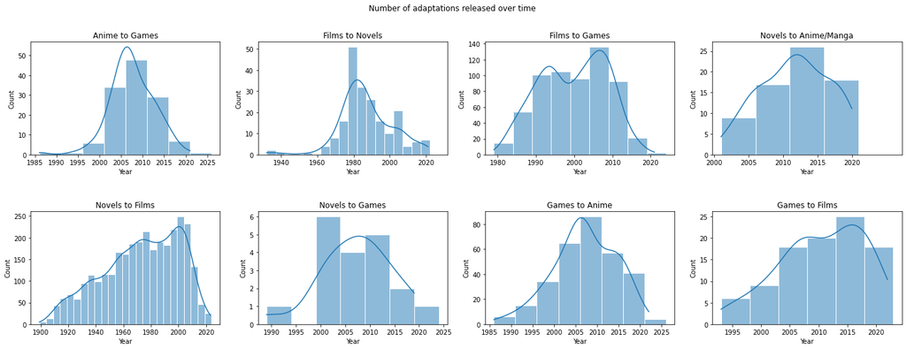

```python
nrow=2
ncol=4

fig = plt.figure(figsize=(24,8))
gs = fig.add_gridspec(nrow, ncol, hspace=0.5, wspace=0.2)
axes = gs.subplots(sharex=False, sharey=False)

count = 0
for r in range(nrow):
    for c in range(ncol):
        ax = axes[r,c]
        dates = dates_data(df_list[count])
        sns.histplot(dates, bins=range(int(dates.min()),2028,5), edgecolor='w', kde=True, ax=ax)
        ax.set_title(df_strings[count])
        ax.set_xlabel("Year")

        # remove floats in axis
        if count == 3:
            ax.set_xticks(range(2000,2021,5))
        count += 1

plt.suptitle("Number of adaptations released over time");
```

It seems that all the graphs largely follow an increasing trend until a peak, and then start decreasing. Most of the graphs peak somewhere in the 21st century, except Films to Novels which peaks at about 1980.  
The graphs are all somewhat skewed left, which is expected, since the number of adaptations would theoretically increase as the number of works produced increases over time. On the contrary, all categories have had fewer adaptations recently (given that the final bin may not be fully accurate due to the incomplete data past 2022, but the trend still holds).

Next, we will examine the popularity of these adaptations over the years.

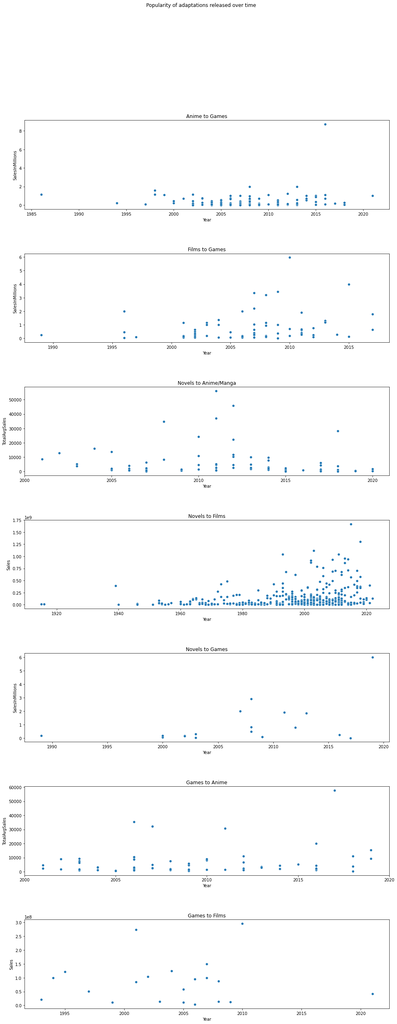

```python
# series where there is relevant data present
df_list2 = [anime_vg_data, film_vg_data, novel_animanga_data, novel_film_films, novel_vg_data, vg_anime_data, vg_film_data]
keys = ['SalesInMillions', 'SalesInMillions', 'TotalAvgSales', 'Sales', 'SalesInMillions', 'TotalAvgSales', 'Sales']
df_strings2 = ['Anime to Games', 'Films to Games', 'Novels to Anime/Manga', 'Novels to Films', 'Novels to Games', 'Games to Anime', 'Games to Films']

nrow=7
ncol=1

fig = plt.figure(figsize=(16,40))
gs = fig.add_gridspec(nrow, ncol, hspace=0.5, wspace=0)
axes = gs.subplots(sharex=False, sharey=False)

count = 0
for r in range(nrow):
    ax = axes[r]
    dates = dates_data(df_list2[count].dropna(subset=keys[count])).dropna()
    sales = df_list2[count].loc[dates.index, keys[count]].dropna()
    sns.scatterplot(x=dates, y=sales, ax=ax)
    ax.set_title(df_strings2[count])
    ax.set_xlabel("Year")
    if count == 2 or count == 5:
        ax.set_xticks(range(2000,2021,5))
    count+=1

plt.suptitle("Popularity of adaptations released over time");
```

Some of the graphs show an increasing trend of sales over the years, while others show no correlation. Additionally, outliers cause the y-limit to be higher than necessary, making most of the points harder to differentiate. I will plot a lineplot of medians in each year instead.

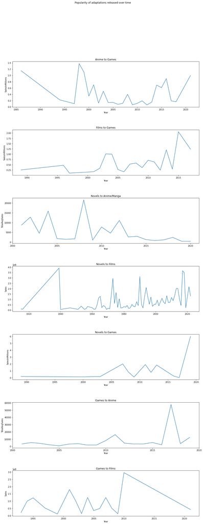

```python
nrow=7
ncol=1

fig = plt.figure(figsize=(16,40))
gs = fig.add_gridspec(nrow, ncol, hspace=0.5, wspace=0)
axes = gs.subplots(sharex=False, sharey=False)

count = 0
for r in range(nrow):
    ax = axes[r]
    dates = dates_data(df_list2[count].dropna(subset=keys[count])).dropna()
    sales = df_list2[count].copy()

    # convert to year if datetime
    if df_list2[count][dates.name].dtype == '<M8[ns]':
        sales[dates.name] = sales[dates.name].dt.year
    sales = sales.groupby(dates.name)[keys[count]].median().dropna()

    sns.lineplot(x=np.sort(dates.unique()), y=sales, ax=ax)
    ax.set_title(df_strings2[count])
    ax.set_xlabel("Year")
    if count == 2 or count == 5:
        ax.set_xticks(range(2000,2021,5))
    count+=1

plt.suptitle("Popularity of adaptations released over time");
```

The graph shows a slightly increasing trend for Novels to Films, while the rest of the categories do not show any significant correlation. While this is unexpected, in some cases (e.g. Games to Films) there might just be too little data for any real trend to be observed.

### Q2. How well do film adaptations sell?

I will now attempt to measure the financial success of movie adaptations.  
Of the data currently available, only Novels to Films and Games to Films are eligible for this.  
I will merge the film data from these two categories and then work on that.

```python
film_adapt_data = pd.concat([vg_film_data,
    novel_film_films.rename(columns={'AdaptTitle':'Title'})])\
    .dropna(subset=['Production Budget', 'Sales'])\
    .reset_index(drop=True)
film_adapt_data.head()
```

|  | Title | AdaptReleaseDate | Production Budget | Sales |
| --- | --- | --- | --- | --- |
| 0 | Super Mario Bros. | 1993-05-28 | 42000000.00 | 20844907.00 |
| 1 | Street Fighter | 1994-12-23 | 35000000.00 | 99423000.00 |
| 2 | Mortal Kombat | 1995-08-18 | 20000000.00 | 122133227.00 |
| 3 | Mortal Kombat: Annihilation | 1997-11-21 | 30000000.00 | 51327406.00 |
| 4 | Wing Commander | 1999-03-12 | 30000000.00 | 11578022.00 |

Finding correlation between sales and budgets with Pearson correlation coefficient:

```python
stats.pearsonr(film_adapt_data['Production Budget'], film_adapt_data['Sales'])
```

```
(0.6658868549696271, 1.0177273926424912e-58)
```

There is generally a moderate positive correlation between sales and budgets, which is natural.

Now, I will create a scatter plot to compare the sales and budgets.

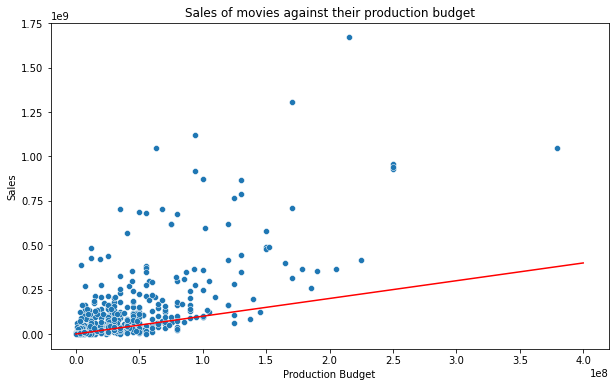

```python
plt.figure(figsize=(10,6))
sns.scatterplot(data=film_adapt_data, x='Production Budget', y='Sales')
plt.plot([0,400000000], [0,400000000], color='red')
plt.title("Sales of movies against their production budget");
```

Zooming in on the region with most of the data points:

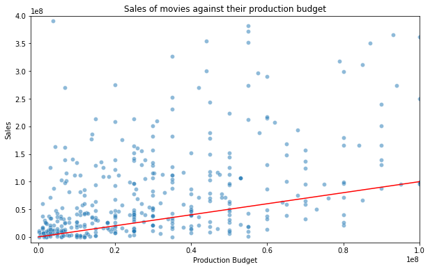

```python
plt.figure(figsize=(10,6))
sns.scatterplot(data=film_adapt_data, x='Production Budget', y='Sales', alpha=0.5)
plt.plot([0,100000000], [0,100000000], color='red')
plt.xlim((-2000000,1.0*10**8))
plt.ylim((-10000000,0.4*10**9))
plt.title("Sales of movies against their production budget");
```

It seems that a majority of the points above the line y=x, which means most movies had more sales than budget, turning a profit.  
(The points also appear to tend to be aligned in columns, which is likely due to production budget mostly being an estimate, so they are rounded to the nearest 'nice number'.)

To better visualise the revenue of these films, I will create a violin plot using revenue, which is (sales - budget).

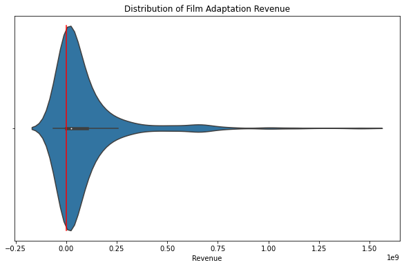

```python
revenue = film_adapt_data['Sales'] - film_adapt_data['Production Budget']

plt.figure(figsize=(10,6))
sns.violinplot(x=revenue)
plt.plot((0,0), (0.4,-0.4), color='red')
plt.xlabel("Revenue")
plt.title("Distribution of Film Adaptation Revenue");
```

From the graph, we can see that the first quartile is approximately 0, and the median and mode are just slightly above that. That is, about 25% of film adaptations actually lose money, and another 25% seem to make a small amount of revenue.  
However, this amount appearing small could be due to the movies with higher revenue simply having more budget, therefore having more sales and revenue, a correlation established earlier.  
I will try to create a fairer distribution by instead finding the ratio of budget to sales, and plotting that. In this case, net losses will result in a ratio of between 0 and 1, while net profits will have a ratio greater than 1.

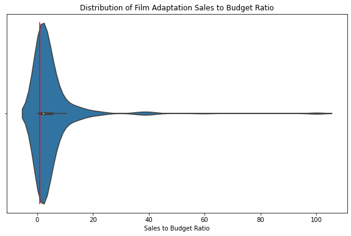

```python
sales_budget_ratio = film_adapt_data['Sales'] / film_adapt_data['Production Budget']

plt.figure(figsize=(10,6))
sns.violinplot(x=sales_budget_ratio)
plt.plot((1,1), (0.4,-0.4), color='red')
plt.xlabel("Sales to Budget Ratio")
plt.title("Distribution of Film Adaptation Sales to Budget Ratio");
```

This graph has a very similar shape to the previous one, which is certainly unexpected. The possible presence of some bias towards more expensive movies in the previous graph has not led to any observable change in this one. (not related to question, covered in appendix at bottom of report)

As a comparison, I will plot the same distribution, but also with all films.

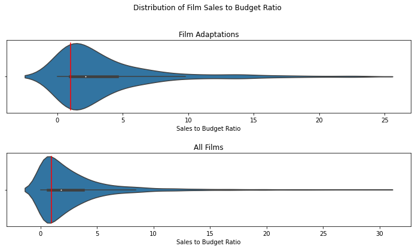

```python
sales_budget_ratio2 = film_data['Sales'] / film_data['Production Budget']
sales_budget_ratio_cut = sales_budget_ratio[sales_budget_ratio < 30]
sales_budget_ratio2_cut = sales_budget_ratio2[sales_budget_ratio2 < 30]

fig, ax = plt.subplots(2, 1, figsize=(10,6))
sns.violinplot(x=sales_budget_ratio_cut, ax=ax[0])
sns.violinplot(x=sales_budget_ratio2_cut, ax=ax[1])
ax[0].set_xlabel("Sales to Budget Ratio")
ax[1].set_xlabel("Sales to Budget Ratio")
ax[0].set_title("Film Adaptations")
ax[1].set_title("All Films")
ax[0].plot((1,1), (-0.4,0.4), color='red')
ax[1].plot((1,1), (-0.4,0.4), color='red')
plt.suptitle("Distribution of Film Sales to Budget Ratio")
fig.tight_layout(pad=2)
```

We see that film adaptations generally have a greater sales to budget ratio than all films. There is also a smaller percentage of film adaptations that make a loss as compared to all films.  
We conclude that, relative to other films, film adaptations sell better.

# Results Findings & Conclusion

For each research question, summarize in 2-3 visualizations which will answer the question. Intrepret the results accordingly and give your observation and conclusion. The visualizations should be well presented (apply what you have learnt in Chapter 9 on data communication). The plots shown here could be an enhanced version of the EDA plots, or presented in another format.

### Q1. How has the number and popularity of adaptations created changed over time?

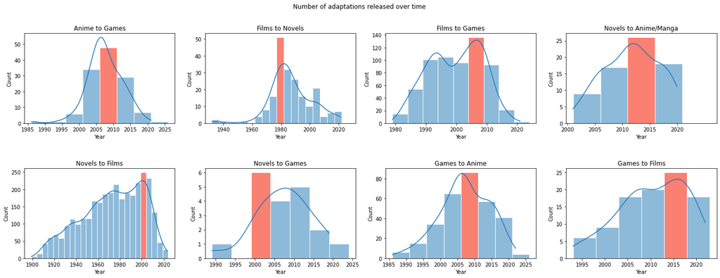

```python
peaks = [4,9,5,2,-5,2,4,-2]
nrow=2
ncol=4

fig = plt.figure(figsize=(24,8))
gs = fig.add_gridspec(nrow, ncol, hspace=0.5, wspace=0.2)
axes = gs.subplots(sharex=False, sharey=False)

count = 0
for r in range(nrow):
    for c in range(ncol):
        ax = axes[r,c]
        dates = dates_data(df_list[count])
        sns.histplot(dates, bins=range(int(dates.min()),2028,5), edgecolor='w', kde=True, ax=ax)
        ax.set_title(df_strings[count])
        ax.set_xlabel("Year")
        ax.patches[peaks[count]].set_fc('salmon')

        # remove floats in axis
        if count == 3:
            ax.set_xticks(range(2000,2021,5))
        count += 1

plt.suptitle("Number of adaptations released over time");
```

Over time, the number of adaptations rises, until a certain peak as highlighted in red, after which the number of adaptations released annually starts decreasing. Most peaks are in the 21st century, except Films to Novels which peaks at about 1980.

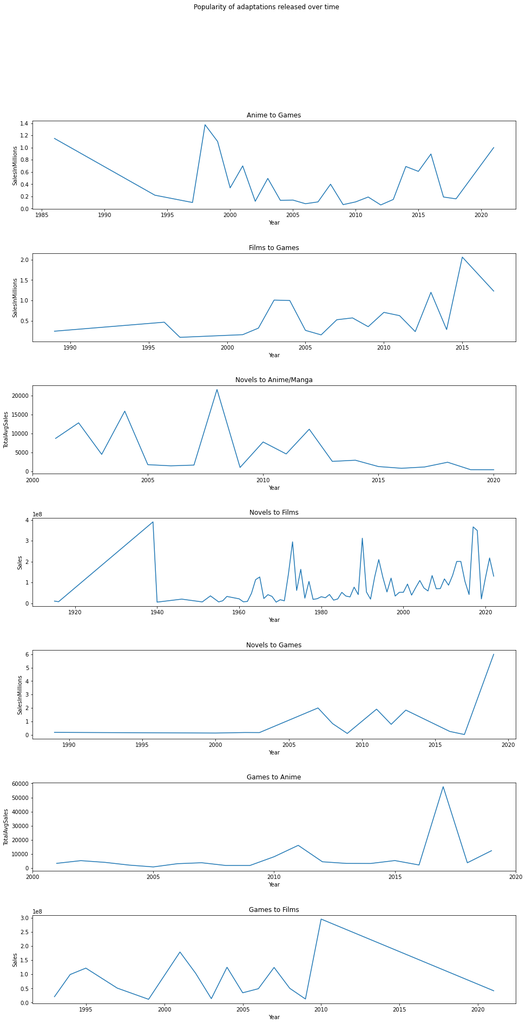

```python
nrow=7
ncol=1

fig = plt.figure(figsize=(16,30))
gs = fig.add_gridspec(nrow, ncol, hspace=0.5, wspace=0)
axes = gs.subplots(sharex=False, sharey=False)

count = 0
for r in range(nrow):
    ax = axes[r]
    dates = dates_data(df_list2[count].dropna(subset=keys[count])).dropna()
    sales = df_list2[count].copy()

    # convert to year if datetime
    if df_list2[count][dates.name].dtype == '<M8[ns]':
        sales[dates.name] = sales[dates.name].dt.year
    sales = sales.groupby(dates.name)[keys[count]].median().dropna()

    sns.lineplot(x=np.sort(dates.unique()), y=sales, ax=ax)
    ax.set_title(df_strings2[count])
    ax.set_xlabel("Year")
    if count == 2 or count == 5:
        ax.set_xticks(range(2000,2021,5))
    count+=1

plt.suptitle("Popularity of adaptations released over time");
```

There does not seem to be any significant correlation, aside from Novels to Films which shows a slightly increasing trend. This could be due to low data volume.

### Q2. How well do film adaptations sell?

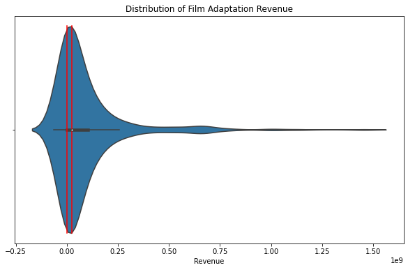

```python
revenue = film_adapt_data['Sales'] - film_adapt_data['Production Budget']

plt.figure(figsize=(10,6))
sns.violinplot(x=revenue)
plt.plot((0,0), (0.4,-0.4), color='red')
plt.plot((0.25*10**8,0.25*10**8), (0.4,-0.4), color='red')
plt.xlabel("Revenue")
plt.title("Distribution of Film Adaptation Revenue");
```

In terms of revenue, about 25% of film adaptations lost money, and the median is at about 25 million.

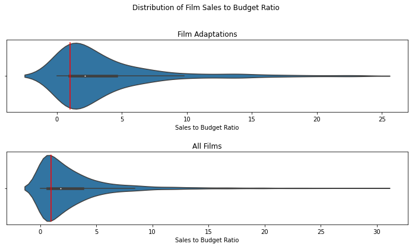

```python
sales_budget_ratio2 = film_data['Sales'] / film_data['Production Budget']
sales_budget_ratio_cut = sales_budget_ratio[sales_budget_ratio < 30]
sales_budget_ratio2_cut = sales_budget_ratio2[sales_budget_ratio2 < 30]

fig, ax = plt.subplots(2, 1, figsize=(10,6))
sns.violinplot(x=sales_budget_ratio_cut, ax=ax[0])
sns.violinplot(x=sales_budget_ratio2_cut, ax=ax[1])
ax[0].set_xlabel("Sales to Budget Ratio")
ax[1].set_xlabel("Sales to Budget Ratio")
ax[0].set_title("Film Adaptations")
ax[1].set_title("All Films")
ax[0].plot((1,1), (-0.4,0.4), color='red')
ax[1].plot((1,1), (-0.4,0.4), color='red')
plt.suptitle("Distribution of Film Sales to Budget Ratio")
fig.tight_layout(pad=2)
```

Film adaptations generally have a greater sales to budget ratio than all films, and a smaller percentage of film adaptations make a loss as compared to all films.  
Therefore, film adaptations sell better than other films, and considering how large the film industry is nowadays, we can conclude that film adaptations sell very well.

# Recommendations or Further Works

State any recommendations, improvements or further works.

Seeing how well film adaptations do, and considering the recent drop in cross-media adaptations produced, I would recommend companies, in particular filmmakers, to make more adaptations.

# Appendix

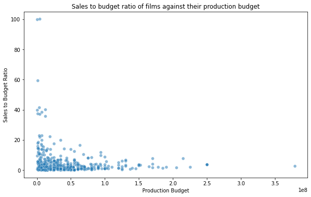

```python
plt.figure(figsize=(10,6))
sns.scatterplot(x=film_adapt_data['Production Budget'], y=sales_budget_ratio, alpha=0.5)
plt.ylabel("Sales to Budget Ratio")
plt.title("Sales to budget ratio of films against their production budget");
```

Some low-budget films have large profits many times larger their budget, while high-budget films which have larger profits than low-budget films do not have as many times more sales as compared to their budgets. There is a weak negative correlation here.

```python
stats.pearsonr(film_adapt_data['Production Budget'], sales_budget_ratio)
```

```
(-0.16295301235157278, 0.0005349822574433591)
```

This result is probably similar for all films, but this project only covers adaptations, so I will not check it.